# Child Mortality: Trends, Inequality and Progress

# Introduction

Child mortality remains one of the most pressing global health issues. While many countries have made great progress, others still face high rates of under-5 deaths. This report explores global patterns, economic links, and regional disparities using UNICEF and World Bank data (1960-2022). It highlights countries that have seen rapid improvement and others where urgent action is still needed.

- Which countries have the highest burden of child deaths?
- How is economic wealth linked to child survival?
- What success stories can inspire global action?

The findings offer a powerful reminder:  
When societies prioritize children’s health and well-being, the future becomes brighter for all.

# 1. Setup, Load, Clean, and Aggregate Data

In this section, I first imported the UNICEF under-five mortality dataset, along with supporting metadata that includes GDP per capita and hospital beds per 1,000 people. After importing, I performed data cleaning by filtering the under-five deaths dataset to include only the “Total” deaths across all sexes, ensuring consistency in the analysis. I also standardized the column names to make the datasets easier to work with. Next, I merged the two datasets based on country and year, so that each record had both mortality information and economic and healthcare indicators. I handled missing data by removing rows where GDP per capita, hospital beds, or under-five deaths were missing, to ensure that the graphs and analysis would be based on complete and reliable information. Finally, I aggregated the data where necessary, such as calculating average values across years for some graphs, in order to observe overall trends from 2012 to 2022. This setup and preparation phase was essential to create a clean, consistent, and meaningful dataset for the visualizations and insights presented in the next sections.

```python
import pandas as pd

# Read UNICEF under-5 deaths data and metadata
ind2 = pd.read_csv("unicef_indicator_2.csv")
meta = pd.read_csv("unicef_metadata.csv")

# Keep only Total-age under-5 deaths, then sum sexes per country-year
mask = (ind2["indicator"] == "Under-five deaths") & (ind2["current_age"] == "Total")
ind2 = ind2.loc[mask, ["country", "time_period", "obs_value"]]
ind2.columns = ["Country", "Year", "Under-5 Deaths"]
ind2 = ind2.groupby(["Country", "Year"], as_index=False).sum()

# Prepare metadata (one record per country-year)
meta = meta.rename(columns={
    "country": "Country",
    "year": "Year",
    "GDP per capita (constant 2015 US$)": "GDP per Capita",
    "Hospital beds (per 1,000 people)": "Hospital Beds"
})
meta = meta[["Country", "Year", "GDP per Capita", "Hospital Beds"]]

# Merge aggregated deaths with metadata
df = pd.merge(ind2, meta, on=["Country", "Year"], how="left")
```

## 2. World Map: Under-5 Deaths

This map shows where child mortality is still a major challenge around the world. Darker shades represent countries with higher numbers of under-five deaths. It’s clear that countries in Sub-Saharan Africa and parts of South Asia face the biggest struggles. By looking at the world this way, we can see that child mortality is not evenly spread—it is concentrated in specific regions where healthcare access and economic conditions remain weak.

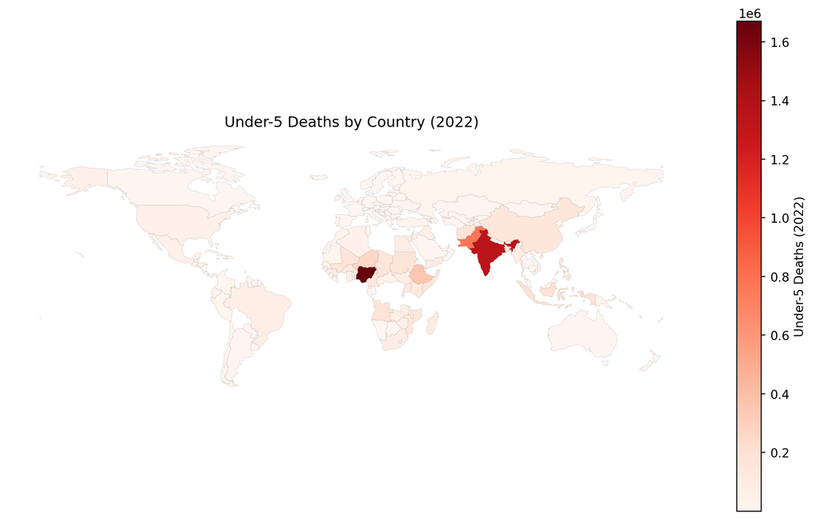

```python
import geopandas as gpd
import cartopy.io.shapereader as shpreader
import matplotlib.pyplot as plt

# Get Natural Earth shapefile
shp_path = shpreader.natural_earth(
    resolution='110m', category='cultural', name='admin_0_countries'
)
world = gpd.read_file(shp_path)

# Merge geometry with aggregated 2022 data
data2022 = df[df.Year == 2022]
chor = world.merge(data2022, left_on='NAME_LONG', right_on='Country', how='left')

# Plot choropleth
fig, ax = plt.subplots(figsize=(10, 6))
chor.plot(
    column='Under-5 Deaths',
    cmap='Reds',
    linewidth=0.1,
    edgecolor='gray',
    legend=True,
    legend_kwds={'label': "Under-5 Deaths (2022)"}
, ax=ax)
ax.set_axis_off()
ax.set_title("Under-5 Deaths by Country (2022)")
plt.tight_layout()
plt.show()
```

## 3. Bar Chart: Top 10 Countries

Here, we highlight the ten countries with the highest number of under-five deaths in 2022. The chart shows that just a few countries—like Nigeria, India, and Pakistan—account for a large share of the global total. Seeing these countries side by side reminds us that targeted action in just a handful of places could save millions of lives. It also shows where urgent support is most needed.

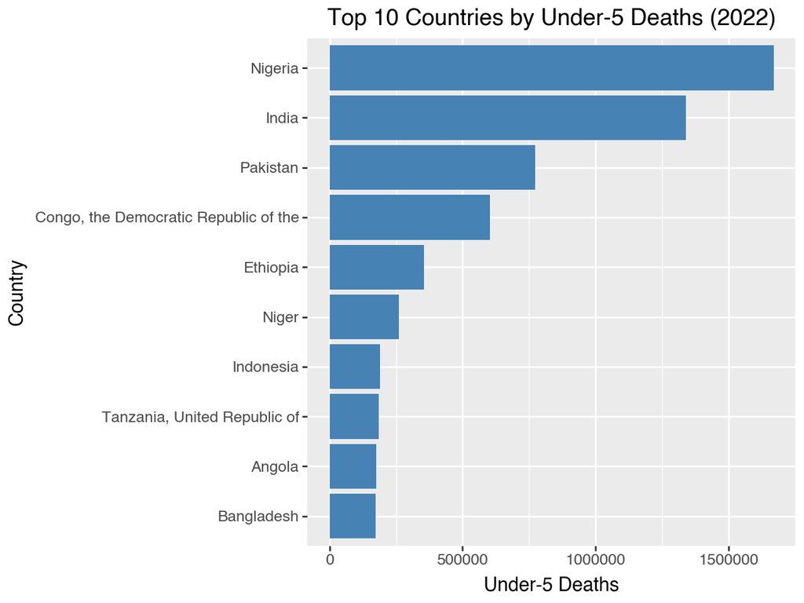

```python
import pandas as pd
from plotnine import ggplot, aes, geom_col, coord_flip, labs

#Pick top 10 and sort ascending for a horizontal bar plot
top10 = (
    df[df.Year == 2022]
    .nlargest(10, "Under-5 Deaths")
    .sort_values("Under-5 Deaths", ascending=True)
    .reset_index(drop=True)
)

#Turn Country into an ordered categorical with that exact ordering
top10["Country"] = pd.Categorical(
    top10["Country"],
    categories=top10["Country"].tolist(),
    ordered=True
)

# Plot using the already‐sorted factor
(
    ggplot(top10, aes(x="Country", y="Under-5 Deaths"))
    + geom_col(fill="steelblue")
    + coord_flip()
    + labs(
        x="Country",
        y="Under-5 Deaths",
        title="Top 10 Countries by Under-5 Deaths (2022)"
    )
)
```

## 4. Scatterplot: GDP vs Child Mortality

This scatterplot explores how a country’s economic status relates to child mortality. We see a clear pattern: countries with higher GDP per capita generally have fewer child deaths. This doesn’t mean that money alone saves lives—but it does show that better resources often lead to better healthcare, nutrition, and living conditions. The downward trend line clearly highlights this connection between wealth and survival.

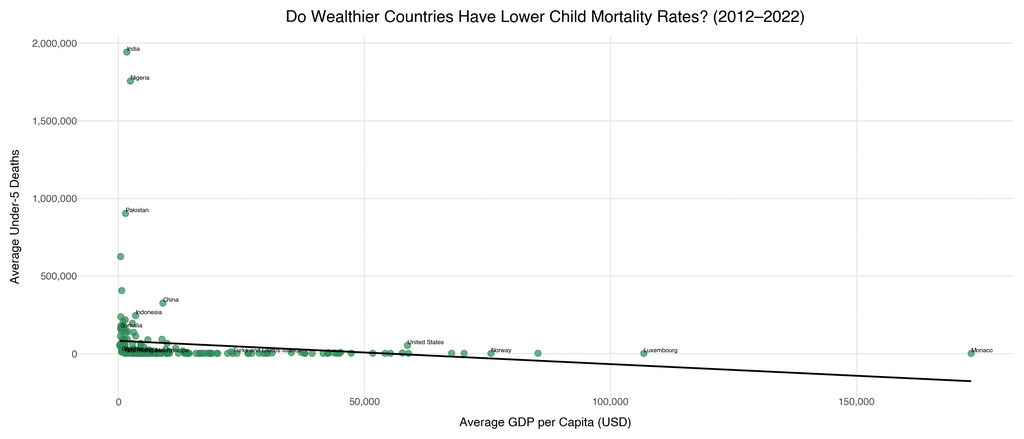

```python
from plotnine import (
    ggplot, aes, geom_point, geom_text, geom_smooth,
    scale_x_continuous, scale_y_continuous, labs, theme_minimal, theme, element_text
)

# Filter data for 2012-2022
sub = df[(df.Year >= 2012) & (df.Year <= 2022)].dropna(subset=["GDP per Capita", "Under-5 Deaths", "Country"])
sub = sub[(sub["GDP per Capita"] > 0) & (sub["Under-5 Deaths"] > 0)]

# FInding the average
sub_avg = sub.groupby("Country", as_index=False).agg({
    "GDP per Capita": "mean",
    "Under-5 Deaths": "mean"
})

# Label important countries
important_countries = [
    'India', 'Nigeria', 'United States', 'China', 'Pakistan', 'Indonesia',
    'Somalia', 'Gambia', 'Kyrgyzstan', 'Sao Tome and Principe',
    'Tonga', 'Nauru', 'Turks and Caicos Islands', 'Norway', 'Luxembourg', 'Monaco'
]

sub_avg["Label"] = sub_avg["Country"].apply(lambda x: x if x in important_countries else "")

# Plot the Scatterplot
(
    ggplot(sub_avg, aes(x="GDP per Capita", y="Under-5 Deaths", label="Label"))
    + geom_point(color="seagreen", size=3, alpha=0.7)
    + geom_text(size=6, va='bottom', ha='left', nudge_y=1000)
    + geom_smooth(method="lm", se=False, color="black")
    + scale_x_continuous(labels=lambda l: ["{:,}".format(int(v)) for v in l])
    + scale_y_continuous(labels=lambda l: ["{:,}".format(int(v)) for v in l])
    + labs(
        title="Do Wealthier Countries Have Lower Child Mortality Rates? (2012–2022)",
        x="Average GDP per Capita (USD)",
        y="Average Under-5 Deaths"
    )
    + theme_minimal()
    + theme(
        figure_size=(14, 6),
        plot_title=element_text(size=16, weight='bold', ha='center'),  # 📢 Center-align title
        axis_title=element_text(size=12),
        axis_text=element_text(size=10)
    )
)
```

## 5. Time Series: India Under-5 Deaths

India’s story is one of hope and steady progress. Over the last 30 years, India has managed to sharply reduce under-five deaths through better healthcare, education, and economic growth. This line chart shows the decline year by year, proving that when countries invest in children’s health, real change is possible. It offers a powerful example for other nations still facing high child mortality rates.

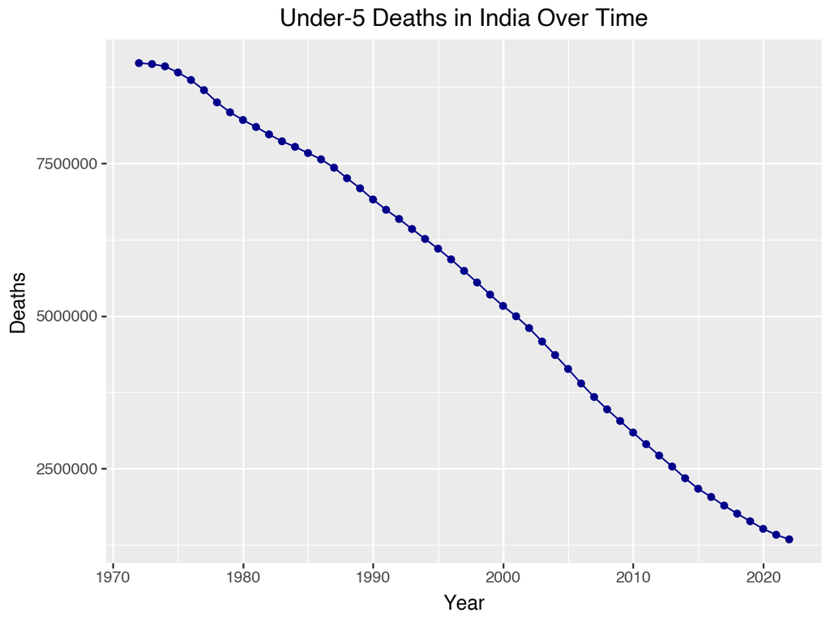

```python
from plotnine import ggplot, aes, geom_line, geom_point, labs

#Filter country india by year from the dataset
india = df[df["Country"] == "India"].sort_values("Year")

#Plot the graph
(
    ggplot(india, aes(x="Year", y="Under-5 Deaths"))
    + geom_line(color="darkblue")
    + geom_point(color="darkblue")
    + labs(
        title="Under-5 Deaths in India Over Time",
        x="Year",
        y="Deaths"
    )
)
```

## 6. Healthcare Access vs Child Mortality

[figure not shown]

```python
import matplotlib.pyplot as plt
import pandas as pd
import numpy as np
import matplotlib.ticker as mticker

# Create continent mapping manually
continent_mapping = {
    'India': 'Asia',
    'Nigeria': 'Africa',
    'United States': 'Americas',
    'China': 'Asia',
    'Pakistan': 'Asia',
    'Indonesia': 'Asia',
    'Somalia': 'Africa',
    'Gambia': 'Africa',
    'Kyrgyzstan': 'Asia',
    'Sao Tome and Principe': 'Africa',
    'Tonga': 'Oceania',
    'Nauru': 'Oceania',
    'Turks and Caicos Islands': 'Americas',
    'Norway': 'Europe',
    'Luxembourg': 'Europe',
    'Monaco': 'Europe'
}

# Map continent
df["Continent"] = df["Country"].map(continent_mapping)

# Filter data
sub_continent = df[(df.Year >= 2012) & (df.Year <= 2022)].dropna(subset=["GDP per Capita", "Under-5 Deaths", "Hospital Beds", "Continent"])

# Group and aggregate
continent_avg = sub_continent.groupby("Continent", as_index=False).agg({
    "Hospital Beds": "mean",
    "Under-5 Deaths": "sum"
})

# Set position for bars
x = np.arange(len(continent_avg["Continent"]))
width = 0.35

# Create plot
fig, ax1 = plt.subplots(figsize=(12, 6))
# Bar 1 - Under-5 Deaths
bar1 = ax1.bar(x - width/2, continent_avg["Under-5 Deaths"], width, color='firebrick', label='Under-5 Deaths')
ax1.set_ylabel('Under-5 Deaths', color='black')
ax1.tick_params(axis='y', labelcolor='black')
ax1.yaxis.set_major_formatter(mticker.FuncFormatter(lambda x, p: format(int(x), ',')))

# Create second y-axis
ax2 = ax1.twinx()
# Bar 2 - Avg Hospital Beds
bar2 = ax2.bar(x + width/2, continent_avg["Hospital Beds"], width, color='royalblue', label='Avg Hospital Beds')
ax2.set_ylabel('Avg. Hospital Beds', color='royalblue')
ax2.tick_params(axis='y', labelcolor='royalblue')

# Title and x-axis
ax1.set_title('Continent-Level View: Higher Healthcare Access Linked to Lower Child Mortality (2012–2022)')
ax1.set_xlabel('Continents')
ax1.set_xticks(x)
ax1.set_xticklabels(continent_avg["Continent"])

# Add legends
fig.legend(loc='upper right', bbox_to_anchor=(1,1), bbox_transform=ax1.transAxes)

plt.tight_layout()
plt.show()
```

## 7. Conclusion

The story of child mortality is one of both heartbreaking loss and hopeful progress.

From my analysis, I see that a relatively small number of countries bear the largest burden of under-five deaths—many concentrated in regions with lower economic development.  
The scatterplot between GDP per capita and child mortality clearly shows that **wealthier countries have fewer child deaths**, mainly due to better healthcare systems, improved nutrition, and wider access to education.

At the same time, individual country success stories—like India’s steady decline in under-five deaths—prove that progress is possible even in low- and middle-income nations.  
With strong leadership, targeted investment, and community-level health programs, many lives can be saved.

**Key Takeaways:**

- Investment in healthcare infrastructure is critical.
- Reducing poverty has a direct impact on child survival.
- Global efforts must continue to focus on the regions most at risk.

Ultimately, every child deserves an equal chance at a healthy life, no matter where they are born.  
By learning from the data and acting on it, we can build a world where child mortality is no longer a tragedy we accept, but a challenge we overcome.

*“The true measure of any society can be found in how it treats its most vulnerable members.”*  
— Mahatma Gandhi